# Regression in Prediction

**Course:** HUDK 4050, Week 5

**Author:** Zhichun Liu

**Assignment:** ICE3

**Objectives:**

At the end of this ICE, you will be able to:

1. build a simple linear regression model to fit data
2. build a multiple regression model to fit data
3. report the results of regression analysis

Hopefully, the previous ICEs have given a good introduction on some basic data manipulation in Python. Starting from this ICE and the ones that follow, we will be taking a closer look at several specific algorithms/methods for Educational Data Mining, starting here with the basic linear regression.

## Linear regression

linear regression models are a good starting point for all kinds of regression tasks. Such models are popular because they can be fit very quickly (blazing fast!), and are very interpretable. You are probably familiar with the simplest form of a linear regression model (i.e., fitting a straight line to data) but such models can be extended to model more complicated data behavior.

If you need a memory refresher about what linear regression is, here is a good intro video to watch: https://youtu.be/nk2CQITm_eo

## Simple linear regression

We will start with the most familiar linear regression, a straight-line fit to data.

$$y = a + bx$$

Here is an example from our `ICE1_Data.csv`:

```python
# Import necessary modules
from sklearn.linear_model import LinearRegression ## This is the module contains LR model
import pandas as pd ## You should be familiar with pandas pretty well now
import matplotlib.pyplot as plt ## This module helps you to plot some results
```

There are three important modules you will need:

- `sklean`: This sci-kit-learn is the most widely used machine learning module in Python. It contains a lot of classical models and algorithms and builds upon `NumPy` and `Pandas`. Here we are only importing the `linear_module` piece in `sklearn` because we just need that much. Later in the course, we will need other models from `sklearn`.
- `pandas as pd`: At this time, you should be pretty familiar with `Pandas`
- `matplotlib`: We have seen this module before. We are using the `pyplot`, a collection of functions that make `matplotlib` work like MATLAB. Each `pyplot` function makes some change to a figure: e.g., creates a figure, creates a plotting area in a figure, plots some lines in a plotting area, decorates the plot with labels, etc.

After importing necessary modules, know let's get the data:

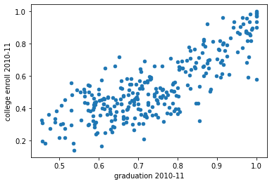

```python
# Import data
school = pd.read_csv("ICE1_Data.csv")
graduationCollege = school[['graduation 2010-11', 'college enroll 2010-11']].dropna()

graduation = graduationCollege.loc[:,"graduation 2010-11"].values.reshape(-1, 1)
college = graduationCollege.loc[:,"college enroll 2010-11"].values.reshape(-1, 1)

graduationCollege.plot.scatter(x = 'graduation 2010-11', y = 'college enroll 2010-11')
```

Here are a couple of things worth noting:

- I am using double bracket `[[]]` after `school` to select multiple variables of interest. We have used this in `ICE1`.
- Then, after selecting the variables of interest, I used `dropna()` to remove the rows that contains `NaN` values. Linear regression cannot work with missing values, so we have to drop them or impute the missing data (topic for another day).
- Once we have the clean (and also tidy) data to work with, we then subset the data with explict indexing into two variables: `graduation` and `college`
- Note that these two variables have to be a "slender" `NumPy array`: That's why we extract their value out first and then use `reshape(-1, 1)` to make it into an array with only 1 column. Here -1 means that calculate the dimension of rows. See the StackOverFlow discussion here on what does `-1` mean: https://stackoverflow.com/questions/18691084/what-does-1-mean-in-numpy-reshape

Once we have the data ready, then fitting the model is just easy-peasy.

**Step 1**: We create a `model` (you can call it anything you like. In practice, I prefer explicit names such as `collegeEnrollModel`. It will really help you remember things you are doing. See more discussion on naming in Python: https://stackoverflow.com/questions/159720/what-is-the-naming-convention-in-python-for-variable-and-function-names)

**Step 2**: Use the `graduation` and `college` data to fit the model.

**Step 3**: Call the `.intercept_` and `.ceof_` to view what do you get.

```python
model = LinearRegression()
model.fit(graduation, college)
print("The intercept is: ", model.intercept_)
print("The slope is: ", model.coef_)
```

```
The intercept is:  [-0.27965123]
The slope is:  [[1.09914898]]
```

In many cases, you may want to see the predicted values. You can call `.predict()` to use x as the input and get predicted ys.

```python
college_pred = model.predict(graduation)
```

Here the scatter plot between `graduation` and `college` is the same. But we are now adding a red line (which is graduation rate against predicted college enroll).

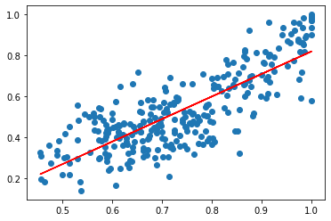

```python
plt.scatter(graduation, college)
plt.plot(graduation, college_pred, color = 'red')
plt.show()
```

## A more realistic example with multiple independent variables

Here we are going to look at some interaction data from students watching on a class video. A project was proposed to collect data from student video watching, a sample of this data is available in the file `ICE3data.csv`.

- `stid` = student id
- `year` = year student watched video
- `participation` = whether or not the student opened the video
- `watch.time` = how long the student watched the video for
- `confusion.points` = how many times a student rewatched a section of a video
- `key.points` = how many times a student skipped or increased the speed of a video

Let's see if we can build a regressor to predict how long the student will watch a video for.

```python
videoData = pd.read_csv("ICE3_data.csv")
videoData
```

|  | stid | year | video | participation | watch.time | confusion.points | key.points |
| --- | --- | --- | --- | --- | --- | --- | --- |
| 0 | 1 | 2018 | A | 1 | 16.5 | 6 | 6 |
| 1 | 2 | 2018 | A | 0 | 0.0 | 0 | 0 |
| 2 | 3 | 2018 | A | 1 | 9.0 | 4 | 6 |
| 3 | 4 | 2018 | A | 1 | 20.0 | 8 | 5 |
| 4 | 5 | 2018 | A | 1 | 12.0 | 8 | 5 |
| ... | ... | ... | ... | ... | ... | ... | ... |
| 295 | 56 | 2019 | E | 1 | 12.0 | 6 | 2 |
| 296 | 57 | 2019 | E | 1 | 17.5 | 10 | 1 |
| 297 | 58 | 2019 | E | 1 | 6.0 | 4 | 1 |
| 298 | 59 | 2019 | E | 0 | 0.0 | 0 | 0 |
| 299 | 60 | 2019 | E | 0 | 0.0 | 0 | 0 |

300 rows × 7 columns

You may want to call `dataFrame.describe()` to first take a quick glance at what is going on. Obviously, we won't be needing `stid` and `year`. And they should really be stored as categorical variables instead of numerical.

```python
videoData.describe()
```

|  | stid | year | participation | watch.time | confusion.points | key.points |
| --- | --- | --- | --- | --- | --- | --- |
| count | 300.000000 | 300.000000 | 300.000000 | 300.000000 | 300.000000 | 300.000000 |
| mean | 30.500000 | 2018.500000 | 0.743333 | 9.302500 | 4.426667 | 2.326667 |
| std | 17.347038 | 0.500835 | 0.437524 | 8.396475 | 3.606658 | 1.921526 |
| min | 1.000000 | 2018.000000 | 0.000000 | 0.000000 | 0.000000 | 0.000000 |
| 25% | 15.750000 | 2018.000000 | 0.000000 | 0.000000 | 0.000000 | 0.000000 |
| 50% | 30.500000 | 2018.500000 | 1.000000 | 8.375000 | 5.000000 | 2.000000 |
| 75% | 45.250000 | 2019.000000 | 1.000000 | 15.750000 | 8.000000 | 4.000000 |
| max | 60.000000 | 2019.000000 | 1.000000 | 32.500000 | 13.000000 | 7.000000 |

Next, let's plot a scatter plot matrix to check (a) the potential linearity among variables, and (b) the distribution of each variable.

[output not shown]

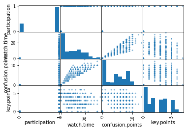

```python
pd.plotting.scatter_matrix(videoData.iloc[:,3:])
```

**A small challenge for you**

From the scatter plot, it looks like watch time, confusion points, as well as key points are all not quite normal. Can you make them normal?

```python
### NORMAL TRANFORMATION
### INSERT YOUR CODE HERE ###
```

For demonstration purpose, let's just use all the variables to predict `watch.time`.

The process is no different than the simple linear model. Just this time, you have multiple Xs:

$$video watch = b_0 + b_1 * participation + b_2 * confusion points + b_3 * key points$$

You will have to prepare a nx3 array for all the Xs and then again the to-be-predicted value -- `watchTime`

Here I am using a different way to create the X matrix because it contains multiple Xs.

```python
Xs = videoData[["participation", "confusion.points", "key.points"]].to_numpy()
watchTime = videoData.loc[:,"watch.time"].values.reshape(-1, 1)
```

Then, the task becomes very easy. Same four lines of codes.

```python
videoModel = LinearRegression()
videoModel.fit(Xs, watchTime)
print("The intercept is: ", videoModel.intercept_)
print("The slope is: ", videoModel.coef_)
```

```
The intercept is:  [-3.55271368e-15]
The slope is:  [[ 0.55757518  2.08731237 -0.15120358]]
```

This type of result can be hard to read sometimes. So, you can try a different Python implementation on linear regression -- `OLS` from `statsmodels` (which means ordinary least sqaure, the algorithm used to estimate each bs in linear regression) . The code are different, but the idea behind is the same. You put the variables into a model, then fit a "line/plane/hyperplane" where minimize the error and obtain the model parameters. `OLS` provides a slightly more comprehensive model summary for us.

```python
from statsmodels.api import OLS
videoModelOLS = OLS(watchTime, Xs)
videoModelOLSFit = videoModelOLS.fit()
print(videoModelOLSFit.summary())
```

```
                                 OLS Regression Results
=======================================================================================
Dep. Variable:                      y   R-squared (uncentered):                   0.919
Model:                            OLS   Adj. R-squared (uncentered):              0.918
Method:                 Least Squares   F-statistic:                              1117.
Date:                Tue, 05 Oct 2021   Prob (F-statistic):                   2.36e-161
Time:                        16:44:43   Log-Likelihood:                         -807.73
No. Observations:                 300   AIC:                                      1621.
Df Residuals:                     297   BIC:                                      1633.
Df Model:                           3
Covariance Type:            nonrobust
==============================================================================
                 coef    std err          t      P>|t|      [0.025      0.975]
------------------------------------------------------------------------------
x1             0.5576      0.844      0.660      0.509      -1.104       2.219
x2             2.0873      0.086     24.137      0.000       1.917       2.257
x3            -0.1512      0.160     -0.945      0.345      -0.466       0.164
==============================================================================
Omnibus:                        7.098   Durbin-Watson:                   2.037
Prob(Omnibus):                  0.029   Jarque-Bera (JB):                7.426
Skew:                          -0.283   Prob(JB):                       0.0244
Kurtosis:                       3.523   Cond. No.                         25.8
==============================================================================

Notes:
[1] R² is computed without centering (uncentered) since the model does not contain a constant.
[2] Standard Errors assume that the covariance matrix of the errors is correctly specified.
```

**Another small challenge for you**

How would interpret the results, How can we interpret individual features/predictors? What would you do next?

For future readings on more advanced issues in regression:

- **regularization in Python**: Regularization helps to solve over fitting problem. Simple model will be a very poor generalization of data. At the same time, complex model may not perform well in test data due to over fitting. We need to choose the right model in between simple and complex model (see here: https://harish-reddy.medium.com/regularization-in-python-699cfbad8622).
- **polynomial and non-linear regression**: Linearity is not always the case, so sometime we need non-linear models such as polynomial regression (see here:https://towardsdatascience.com/polynomial-regression-bbe8b9d97491) or other non-linear model such as decision tree (see here: https://www.geeksforgeeks.org/python-decision-tree-regression-using-sklearn/)
- **variable selection**: In real world analytics, we often come across a large volume of candidate regressors, but most end up not being useful in regression modeling. Finding the most appropriate set of regressors is a variable selection issue. (see here: https://www.datasklr.com/ols-least-squares-regression/variable-selection)

## Your Tasks for ICE 3

For ICE 3, you may want to:

1. follow my tutorial and learn how to run linear regression in Python
2. think about what are you going to do with this method (e.g., implications and applications)
3. keep good record of your ICEs. Save the .ipynb files in a same place. You will need them later.